# R Notebook

**The motivation for the project is to see on what basis stars are assigned to hotels and which attributes influence them.**

**Our class label is ” hotel stars”, and after several experiments we discovered that the attributes affecting it were (Pool + Gym + Spa + Free.internet + Tennis.court + Casino), so we chose it, but the rest did not make a difference in the result.**

**We will predict the Hotel star based on (Pool + Gym + Spa + Free.internet + Tennis.court + Casino)**

**read the dataset**

```r
View(dataset)
str(dataset)
```

```
'data.frame':   502 obs. of  20 variables:
 $ User.country     : Factor w/ 48 levels "1","2","3","4",..: 39 39 39 2 3 3 2 39 4 3 ...
 $ Nr..reviews      : int  11 119 36 14 5 31 45 2 24 12 ...
 $ Nr..hotel.reviews: int  4 21 9 7 5 8 12 1 3 7 ...
 $ Helpful.votes    : int  13 75 25 14 2 27 46 4 8 11 ...
 $ Score            : num  1 0.5 1 0.75 0.75 0.5 0.75 0.75 0.75 0.5 ...
 $ Period.of.stay   : Factor w/ 4 levels "1","2","3","4": 1 1 2 2 2 2 2 2 2 2 ...
 $ Traveler.type    : Factor w/ 5 levels "0","1","2","3",..: 1 5 3 1 2 4 4 3 1 3 ...
 $ Pool             : Factor w/ 2 levels "0","1": 1 1 1 1 1 1 1 1 1 1 ...
 $ Gym              : Factor w/ 2 levels "0","1": 2 2 2 2 2 2 2 2 2 2 ...
 $ Tennis.court     : Factor w/ 2 levels "0","1": 1 1 1 1 1 1 1 1 1 1 ...
 $ Spa              : Factor w/ 2 levels "0","1": 1 1 1 1 1 1 1 1 1 1 ...
 $ Casino           : Factor w/ 2 levels "0","1": 2 2 2 2 2 2 2 2 2 2 ...
 $ Free.internet    : Factor w/ 2 levels "0","1": 2 2 2 2 2 2 2 2 2 2 ...
 $ Hotel.name       : Factor w/ 21 levels "0","1","2","3",..: 1 1 1 1 1 1 1 1 1 1 ...
 $ Hotel.stars      : num  3 3 3 3 3 3 3 3 3 3 ...
 $ Nr..rooms        : int  3773 3773 3773 3773 3773 3773 3773 3773 3773 3773 ...
 $ User.continent   : Factor w/ 6 levels "0","1","2","3",..: 1 1 1 2 1 1 2 1 3 1 ...
 $ Member.years     : int  9 3 2 6 7 2 4 0 3 5 ...
 $ Review.month     : Factor w/ 12 levels "0","1","2","3",..: 5 5 4 4 8 8 1 1 9 9 ...
 $ Review.weekday.  : Factor w/ 7 levels "0","1","2","3",..: 1 2 3 2 4 4 2 4 3 4 ...
```

**pie chart for Traveler.type**

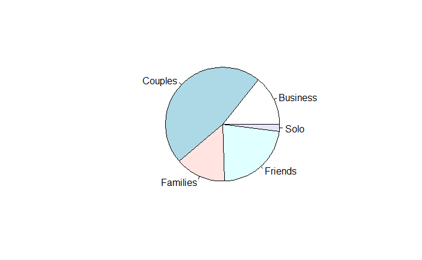

```r
library(dplyr)
dataset2 <- dataset %>% sample_n(49)
dataset2$Traveler.type %>% table() %>% pie() # plot pie chart without percentages
```

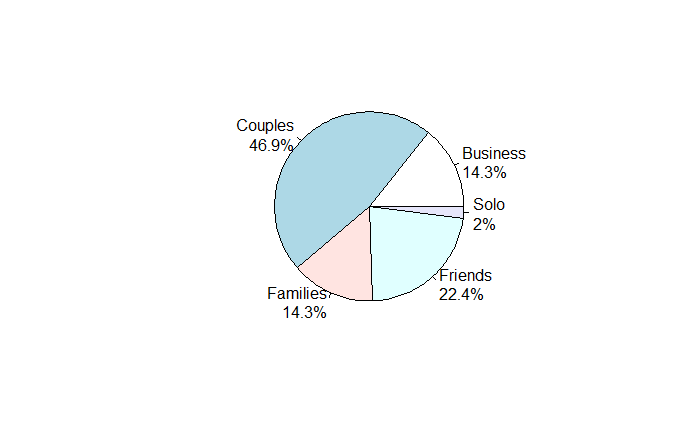

```r
tab <- dataset2$Traveler.type %>% table()
precentages <- tab %>% prop.table() %>% round(3) * 100
txt <- paste0(names(tab), '\n', precentages, '%') # text on chart
pie(tab, labels=txt) # plot pie chart
```

**encoding for all the atribiue**

```r
#encoding
dataset$User.country =factor(dataset$User.country, levels = c("Saudi Arabia", "UK", "Canada", "India", "Australia", "New Zeland", "Ireland", "Egypt", "Finland", "Kenya", "Jordan", "Netherlands", "Syria", "Scotland", "South Africa", "Swiss", "United Arab Emirates", "Hungary", "China", "Greece", "Mexico", "Croatia", "Germany", "Malaysia", "Thailand", "Phillippines", "Israel", "India", "Belgium", "Puerto Rico", "Switzerland", "Norway", "France", "Spain", "Singapore", "Brazil", "Costa Rica", "Iran", "USA", "Honduras", "Denmark", "Taiwan", "Hawaii", "Kuwait", "Czech Republic", "Japan", "Korea", "Italy"),
                          labels =c(1, 2, 3, 4, 5, 6, 7, 8, 9, 10, 11, 12, 13, 14, 15, 16, 17, 18, 19, 20, 21, 22, 23, 24, 25, 26, 27, 28, 29, 30, 31, 32, 33, 34, 35, 36, 37, 38, 39, 40, 41, 42, 43, 44, 45, 46, 47, 48))
#to integer
#dataset$User.country <- as.integer(dataset$User.country)


dataset$Gym =factor(dataset$Gym, levels = c("NO", "YES"), labels = c(0, 1))
dataset$Tennis.court =factor(dataset$Tennis.court, levels = c("NO", "YES"), labels = c(0, 1))

dataset$Spa =factor(dataset$Spa, levels = c("NO", "YES"), labels = c(0, 1))

dataset$Casino =factor(dataset$Casino, levels = c("NO", "YES"), labels = c(0, 1))
dataset$Free.internet =factor(dataset$Free.internet, levels = c("NO", "YES"), labels = c(0, 1))

dataset$Pool =factor(dataset$Pool, levels = c("NO", "YES"), labels = c(0, 1))

dataset$Period.of.stay =factor(dataset$Period.of.stay, levels = c("Dec-Feb", "Mar-May","Jun-Aug","Sep-Nov"), labels = c(1, 2, 3, 4))


dataset$Review.weekday. =factor(dataset$Review.weekday , levels = c("Thursday","Thursday,","Friday","Friday,","Saturday","Saturday,","Tuesday","Tuesday,","Wednesday","Wednesday,","Sunday","Sunday,","Monday","Monday,"), labels = c(0,0,1,1,2,2,3,3,4,4,5,5,6,6))
dataset$Traveler.type =factor(dataset$Traveler.type, levels = c("Friends","Solo","Families","Couples","Business"), labels = c(0,1,2,3,4))

dataset$Hotel.name =factor(dataset$Hotel.name, levels = c("Circus Circus Hotel & Casino Las Vegas","Excalibur Hotel & Casino", "Monte Carlo Resort&Casino", "Treasure Island- TI Hotel & Casino", "Tropicana Las Vegas - A Double Tree by Hilton Hotel", "Caesars Palace", "The Cosmopolitan Las Vegas", "The Palazzo Resort Hotel Casino", "Wynn Las Vegas", "Trump International Hotel Las Vegas", "The Cromwell", "Encore at wynn Las Vegas", "Hilton Grand Vacations on the Boulevard", "Marriott's Grand Chateau", "Tuscany Las Vegas Suites & Casino", "Hilton Grand Vacations at the Flamingo", "Wyndham Grand Desert", "The Venetian Las Vegas Hotel", "Bellagio Las Vegas", "Paris Las Vegas", "The Westin las Vegas Hotel Casino & Spa")
                           , labels = c(0,1,2,3,4,5,6,7,8,9,10,11,12,13,14,15,16,17,18,19,20))

dataset$Review.month =factor(dataset$Review.month, levels = c("April","August", "December", "February", "January", "July", "June", "March", "May", "November", "October", "September")
                           , labels = c(0,1,2,3,4,5,6,7,8,9,10,11))

dataset$User.continent=factor(dataset$User.continent, levels=c("North America","Europe","Asia","Oceania","Africa","South America"), labels=c(0,1,2,3,4,5))
```

**finding outliers AND remove outliers**

**NOTE: RUN THE CODE TWICE WE HAVE TWO OUTLIERS**

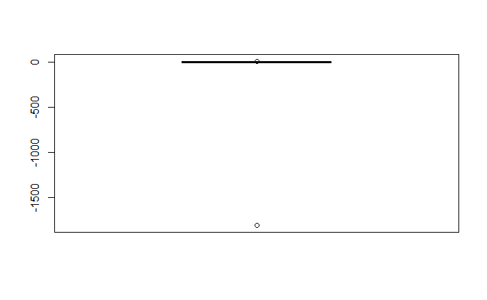

```r
#outlaier
boxplot(dataset$Member.years)
```

```r
library(outliers)

Out = outlier(dataset$Member.years, logical =TRUE)
sum(Out)
```

```
[1] 1
```

```r
Find_outlier = which(Out ==TRUE, arr.ind = TRUE)
Out
```

[output not shown]

[output cut: 19 more lines]

```r
Find_outlier
```

```
[1] 76
```

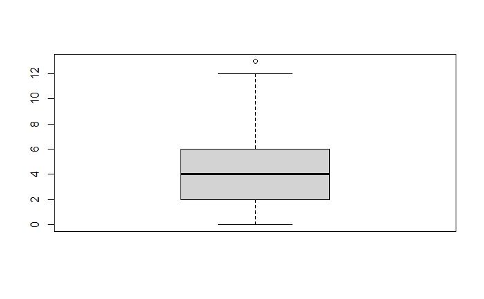

```r
#Remove outlier
dataset= dataset[-Find_outlier,]

boxplot(dataset$Member.years)
```

```r
View(dataset)

quantile(dataset$Member.years)
```

```
  0%  25%  50%  75% 100%
   0    2    4    6   13
```

```r
Out = outlier(dataset$Member.years, logical =TRUE)
sum(Out)
```

```
[1] 1
```

```r
Find_outlier = which(Out ==TRUE, arr.ind = TRUE)
Out
```

[output not shown]

[output cut: 19 more lines]

```r
Find_outlier
```

```
[1] 143
```

**normalization**

```r
#normalization
dataWithoutNormalization <- dataset

dataset [, 5] = scale(dataset [, 5])

#Define function normalize().
normalize <- function(x) {return ((x - min(x)) / (max(x) - min(x)))}
#Define function Z_normalize().
Z_normalize <- function(x) {return ((x - mean(x)) / sd(x))}

#Call normalize funcrtion
dataset$Score<-normalize(dataWithoutNormalization$Score)
```

**missing data**

```r
is.na(dataset)
sum(is.na(dataset))
dataset= dataset[-104,]
```

**pie chart for Period.of.stay**

```r
library(dplyr)
dataset2 <- dataset %>% sample_n(49)
dataset2$Period.of.stay %>% table() %>% pie() # plot pie chart without percentages
tab <- dataset2$Period.of.stay %>% table()
precentages <- tab %>% prop.table() %>% round(3) * 100
txt <- paste0(names(tab), '\n', precentages, '%') # text on chart
pie(tab, labels=txt) # plot pie chart
```

[output not shown]

```r
library(dplyr)
dataset2 <- dataset %>% sample_n(49)
dataset2$Period.of.stay %>% table() %>% pie() # plot pie chart without percentages
tab <- dataset2$Hotel.stars %>% table()
precentages <- tab %>% prop.table() %>% round(3) * 100
txt <- paste0(names(tab), '\n', precentages, '%') # text on chart

pie(tab, labels=txt) # plot pie chart
```

[output not shown]

**2 histograms for User.country and Hotel.name**

```r
dataset$User.country <- as.integer(dataset$User.country)
dataset$Hotel.name <- as.integer(dataset$Hotel.name)


hist(dataset$User.country, breaks=48)
hist(dataset$Hotel.name, breaks=20)
```

[output not shown]

**scatter**

```r
with(dataset, plot(Score,Hotel.stars, col = Pool, pch = as.numeric(Pool)))
```

[output not shown]

**preprossing to invert the attrbiute to factors**

```r
yes<-dataset
yes$Hotel.stars <- as.factor(yes$Hotel.stars)
yes$Pool <- as.factor(yes$Pool)
yes$Gym <- as.factor(yes$Gym)
yes$Spa <- as.factor(yes$Spa)
yes$Free.internet <- as.factor(yes$Free.internet)
yes$Tennis.court <- as.factor(yes$Tennis.court)
yes$Casino <- as.factor(yes$Casino)
```

**classification-gini index - 1 (Training 80%, Test 20%)**

If a gym is present (‘Gym = 1’), then the decision goes to the presence of a pool. If there is no pool, it further splits based on the presence of a casino and tennis court, leading to various predictions. The presence of a pool leads to different star ratings. If there is no gym, the model predicts a 3-star rating.

```r
#install.packages("rpart")
#install.packages("rpart.plot")

library(rpart)
library(rpart.plot)
dataset.H <- yes

set.seed(234)
train1 = sample(1:nrow(dataset.H), 400)
dataset.train1=dataset.H[train1,]
dataset.test1=dataset.H[-train1,]
Hotel.stars.test1=dataset.H[-train1]
str(dataset.train1)

fit.tree = rpart(Hotel.stars ~ Pool + Gym + Spa + Free.internet + Tennis.court + Casino , data=dataset.train1, method = "class", cp=0.002)
fit.tree
rpart.plot(fit.tree)


#try to save it in pdf file to view it clearly
pdf("tree_plot4.pdf", width = 12, height = 8)
rpart.plot(fit.tree)
dev.off()



predictions <- predict(fit.tree, dataset.test1, type = "class")

# Confusion matrix
conf_matrix <- table(predictions, dataset.test1$Hotel.stars)

# Calculate accuracy
accuracy <- sum(diag(conf_matrix)) / sum(conf_matrix)
cat("Accuracy:", accuracy, "\n")

# Display confusion matrix
conf_matrix
```

[output not shown]

**classification-gini index - 2 (Training 90%, Test 10%)**

The path of the decision tree same as the above tree.The model’s accuracy is 0.6862745%, meaning that in approximately 69 out of 100 cases, the model will correctly predict the star rating of a hotel based on these amenities.

```r
#install.packages("rpart")
#install.packages("rpart.plot")
library(rpart)
library(rpart.plot)



set.seed(234)
train1 = sample(1:nrow(dataset.H), 450)
dataset.train1=dataset.H[train1,]
dataset.test1=dataset.H[-train1,]
Hotel.stars.test1=dataset.H[-train1]
str(dataset.train1)

fit.tree = rpart(Hotel.stars ~ Pool + Gym + Spa + Free.internet + Tennis.court + Casino , data=dataset.train1, method = "class", cp=0.002)
fit.tree
rpart.plot(fit.tree)


#try to save it in pdf file to view it clearly
pdf("tree_plot4.pdf", width = 12, height = 8)
rpart.plot(fit.tree)
dev.off()



predictions <- predict(fit.tree, dataset.test1, type = "class")

# Confusion matrix
conf_matrix <- table(predictions, dataset.test1$Hotel.stars)

# Calculate accuracy
accuracy <- sum(diag(conf_matrix)) / sum(conf_matrix)
cat("Accuracy:", accuracy, "\n")

# Display confusion matrix
conf_matrix
```

[output not shown]

```r
#install.packages("rpart")
#install.packages("rpart.plot")
library(rpart)
library(rpart.plot)




set.seed(234)
train1 = sample(1:nrow(dataset.H), 350)
dataset.train1=dataset.H[train1,]
dataset.test1=dataset.H[-train1,]
str(yes)
Hotel.stars.test1=dataset.H[-train1]
str(dataset.train1)

fit.tree = rpart(Hotel.stars ~ Pool + Gym + Spa + Free.internet + Tennis.court + Casino , data=dataset.train1, method = "class", cp=0.002)
fit.tree
rpart.plot(fit.tree)


#try to save it in pdf file to view it clearly
pdf("tree_plot4.pdf", width = 12, height = 8)
rpart.plot(fit.tree)
dev.off()



predictions <- predict(fit.tree, dataset.test1, type = "class")

# Confusion matrix
conf_matrix <- table(predictions, dataset.test1$Hotel.stars)

# Calculate accuracy
accuracy <- sum(diag(conf_matrix)) / sum(conf_matrix)
cat("Accuracy:", accuracy, "\n")

# Display confusion matrix
conf_matrix
```

[output not shown]

**classification-information gain - 1 (Training 70%,Test 30%)**

This decision tree represent a predictive model for hotel star ratings based on amenities such as a gym, spa, pool, tennis court, casino, and free internet. The method used for creating the tree is based on information gain from the highest to the Lowest information gain , which is a criterion for splitting the data in a way that maximizes the reduction of uncertainty The overall accuracy of the model is 71.62162%, which means it correctly predicts the star rating of a hotel based on these features about 71.6% of the time. This metric gives an indication of the model’s performance on the dataset it was tested on

```r
set.seed(1234)
ind <- sample(2, nrow(yes), replace=TRUE, prob=c(0.7, 0.3))
trainData <- yes[ind==1,]
testData <- yes[ind==2,]

#install.packages('party')
library(party)
myFormula <- Hotel.stars ~ Pool + Gym + Spa + Free.internet + Tennis.court + Casino
dataset_ctree <- ctree(myFormula, data=trainData)

table(predict(dataset_ctree), trainData$Hotel.stars)
print(dataset_ctree)
plot(dataset_ctree,type="simple")
plot(dataset_ctree)



# predict on test data
testPred <- predict(dataset_ctree, newdata = testData)
table(testPred, testData$Hotel.stars)



#install.packages('caret')
library(caret)
results <- confusionMatrix(testPred, testData$Hotel.stars)
acc <- results$overall["Accuracy"]*100
acc
results
as.table(results)
as.matrix(results)
as.matrix(results, what = "overall")
as.matrix(results, what = "classes")
print(results)
```

[output not shown]

**classification-information gain - 2 (Training 80%, Test 20%)**

The path of the decision tree same as the above trees.The overall accuracy of the model is 69%, which means it correctly predicts the star rating of a hotel based on these features about 69% of the time. This metric gives an indication of the model’s performance on the dataset it was tested on

```r
set.seed(1234)
ind <- sample(2, nrow(yes), replace=TRUE, prob=c(0.8, 0.2))
trainData <- yes[ind==1,]
testData <- yes[ind==2,]

#install.packages('party')
library(party)

myFormula <- Hotel.stars ~ Pool + Gym + Spa + Free.internet + Tennis.court + Casino
dataset_ctree <- ctree(myFormula, data=trainData)

table(predict(dataset_ctree), trainData$Hotel.stars)
print(dataset_ctree)
plot(dataset_ctree,type="simple")
plot(dataset_ctree)



testPred <- predict(dataset_ctree, newdata = testData)
table(testPred, testData$Hotel.stars)

#install.packages('caret')
library(caret)
results <- confusionMatrix(testPred, testData$Hotel.stars)
acc <- results$overall["Accuracy"]*100
acc
results
as.table(results)
as.matrix(results)
as.matrix(results, what = "overall")
as.matrix(results, what = "classes")
print(results)
```

[output not shown]

**classification-information gain - 3 (Training 90%, Test 10%)**

The path of the decision tree same as the above trees.The overall accuracy of the model is 66%, which means it correctly predicts the star rating of a hotel based on these features about 66% of the time. This metric gives an indication of the model’s performance on the dataset it was tested on

```r
set.seed(1234)
ind <- sample(2, nrow(yes), replace=TRUE, prob=c(0.9, 0.1))
trainData <- yes[ind==1,]
testData <- yes[ind==2,]

#install.packages('party')
library(party)

myFormula <- Hotel.stars ~ Pool + Gym + Spa + Free.internet + Tennis.court + Casino
dataset_ctree <- ctree(myFormula, data=trainData)

table(predict(dataset_ctree), trainData$Hotel.stars)
print(dataset_ctree)
plot(dataset_ctree,type="simple")
plot(dataset_ctree)



# predict on test data
testPred <- predict(dataset_ctree, newdata = testData)
table(testPred, testData$Hotel.stars)

#install.packages('caret')
library(caret)
results <- confusionMatrix(testPred, testData$Hotel.stars)
acc <- results$overall["Accuracy"]*100
acc
results
as.table(results)
as.matrix(results)
as.matrix(results, what = "overall")
as.matrix(results, what = "classes")
print(results)
```

[output not shown]

**classification- gain ratio - 1 (3 folds)**

The path of the decision tree same as the above trees.The overall accuracy of the model is 70%, which means it correctly predicts the star rating of a hotel based on these features about 70% of the time. This metric gives an indication of the model’s performance on the dataset it was tested on

```r
set.seed(1958)
folds <- createFolds(yes$Hotel.stars, k = 3)

# Specify 'method' as "J48" and 'trControl' for classification
C45Fit <- train(Hotel.stars ~ Pool + Gym + Spa + Free.internet + Tennis.court + Casino ,method = "J48", data = yes, tuneLength = 5, trControl = trainControl(method = "cv", index = folds))
C45Fit
C45Fit$finalModel


#install.packages("partykit")
library(partykit)


#visualize
constparty_model <- as.constparty(C45Fit$finalModel)
plot(constparty_model)




# Create test set
test <- yes[-folds$Fold1, ]

# Make predictions on the test set
predictions <- predict(C45Fit, newdata = test)

# Confusion matrix
conf_matrix <- table(predictions, test$Hotel.stars)

# Calculate accuracy
accuracy <- sum(diag(conf_matrix)) / sum(conf_matrix)
cat("Accuracy:", accuracy, "\n")

# Display confusion matrix
conf_matrix
```

[output not shown]

**classification- gain ratio - 2 (5 folds)**

The path of the decision tree same as the above trees.The overall accuracy of the model is 70%, which means it correctly predicts the star rating of a hotel based on these features about 70% of the time. This metric gives an indication of the model’s performance on the dataset it was tested on

```r
set.seed(1958)
folds <- createFolds(yes$Hotel.stars, k = 5)

C45Fit <- train(Hotel.stars ~ Pool + Gym + Spa + Free.internet + Tennis.court + Casino ,method = "J48", data = yes, tuneLength = 5, trControl = trainControl(method = "cv", index = folds))
C45Fit
C45Fit$finalModel


#install.packages("partykit")
library(partykit)


constparty_model <- as.constparty(C45Fit$finalModel)
plot(constparty_model)




test <- yes[-folds$Fold1, ]

predictions <- predict(C45Fit, newdata = test)

conf_matrix <- table(predictions, test$Hotel.stars)

accuracy <- sum(diag(conf_matrix)) / sum(conf_matrix)
cat("Accuracy:", accuracy, "\n")

conf_matrix
```

[output not shown]

**classification- gain ratio - 3 (10 folds)**

The path of the decision tree same as the above trees.The overall accuracy of the model is 70%, which means it correctly predicts the star rating of a hotel based on these features about 70% of the time. This metric gives an indication of the model’s performance on the dataset it was tested on

```r
set.seed(1958)
folds <- createFolds(yes$Hotel.stars, k = 10)

C45Fit <- train(Hotel.stars ~ Pool + Gym + Spa + Free.internet + Tennis.court + Casino ,method = "J48", data = yes, tuneLength = 5, trControl = trainControl(method = "cv", index = folds))
C45Fit
C45Fit$finalModel


#install.packages("partykit")
library(partykit)


#visualize
constparty_model <- as.constparty(C45Fit$finalModel)
plot(constparty_model)




test <- yes[-folds$Fold1, ]

predictions <- predict(C45Fit, newdata = test)

conf_matrix <- table(predictions, test$Hotel.stars)

accuracy <- sum(diag(conf_matrix)) / sum(conf_matrix)
cat("Accuracy:", accuracy, "\n")

conf_matrix
```

[output not shown]

Our accuracy is constant in gain ratio method because of our dataset is small, changing the number of folds may not have a significant impact on model performance. Cross-validation is generally more effective with larger datasets.

**clustring prepreocessing Data types should be transformed into numeric types before clustering.**

```r
yes1<-yes
yes1$Pool <- as.numeric(yes1$Pool)
yes1$Gym <- as.numeric(yes1$Gym)
yes1$Spa <- as.numeric(yes1$Spa)
yes1$Free.internet <- as.numeric(yes1$Free.internet)
yes1$Tennis.court <- as.numeric(yes1$Tennis.court)
yes1$Casino <- as.numeric(yes1$Casino)

View(yes1)
```

**Create a new dataset with only numeric attributes**

```r
new_dataset <- yes1[, sapply(yes1, is.numeric)]

new_dataset <- scale(new_dataset)
View(new_dataset)

# Specify the subset of attributes for clustering
subset_attributes <- c("Pool", "Gym", "Spa", "Free.internet", "Tennis.court", "Casino")

# Subset the dataset to include only the specified attributes
subset_dataset <- new_dataset[, subset_attributes]
```

**BCubed precision and recall**

```r
# Function to calculate BCubed precision for a specific class label in a cluster
calculate_BCubed_precision <- function(cluster_assignments, true_labels, class_label) {
  num_points <- length(cluster_assignments)
  precision_sum <- 0

  for (i in 1:num_points) {
    cluster_indices <- which(cluster_assignments == cluster_assignments[i])
    class_indices <- which(true_labels == class_label)

    common_indices <- length(intersect(cluster_indices, class_indices))
    cluster_size <- length(cluster_indices)

    precision_sum <- precision_sum + (common_indices / cluster_size)
  }

  BCubed_precision <- precision_sum / num_points
  return(BCubed_precision)
}

# Function to calculate BCubed recall for a specific class label in a cluster
calculate_BCubed_recall <- function(cluster_assignments, true_labels, class_label) {
  num_points <- length(cluster_assignments)
  recall_sum <- 0

  for (i in 1:num_points) {
    cluster_indices <- which(cluster_assignments == cluster_assignments[i])
    class_indices <- which(true_labels == class_label)

    common_indices <- length(intersect(cluster_indices, class_indices))
    class_size <- length(class_indices)

    recall_sum <- recall_sum + (common_indices / class_size)
  }

  BCubed_recall <- recall_sum / num_points
  return(BCubed_recall)
}
```

```r
# Specify the class labels (replace with actual class labels in your data)
class_labels <- c("3", "3,5", "4", "4,5","5")

# Calculate BCubed precision and recall for each class label
BCubed_precision_recall_results <- matrix(NA, nrow = length(class_labels), ncol = 2,
                                          dimnames = list(class_labels, c("BCubed_Precision", "BCubed_Recall")))
```

**run k-means clustering to find 4 clusters**

```r
set.seed(8953)



kmeans.result <- kmeans(subset_dataset, 4)
kmeans.result


#3- visualize clustering
#install.packages("factoextra")
library(factoextra)
fviz_cluster(kmeans.result, data = subset_dataset)

kmeans.result$tot.withinss

#silhouette
library(cluster)
avg_sil <- silhouette(kmeans.result$cluster,dist(subset_dataset)) #a dissimilarity object inheriting from class dist or coercible to one. If not specified, dmatrix must be.
fviz_silhouette(avg_sil)#k-means clustering with estimating k and initializations

#BCubed precision and recall
for (i in 1:length(class_labels)) {
  BCubed_precision_recall_results[i, 1] <- calculate_BCubed_precision(kmeans.result$cluster, yes1$Hotel.stars, class_labels[i])
  BCubed_precision_recall_results[i, 2] <- calculate_BCubed_recall(kmeans.result$cluster, yes1$Hotel.stars, class_labels[i])
}



# View the results
print(BCubed_precision_recall_results)
#print(BCubed_precision_recall_results)
#BCubed_Precision BCubed_Recall
#3         0.19161677     0.4401198
#3,5       0.14371257     0.5708583
#4         0.23552894     0.6537095
#4,5       0.04790419     0.8083832
#5         0.38123752     0.8083832
```

[output not shown]

**run k-means clustering to find 2 clusters**

```r
set.seed(8953)



kmeans.result2 <- kmeans(subset_dataset, 2)
kmeans.result2


#3- visualize clustering
library(factoextra)
fviz_cluster(kmeans.result2, data = subset_dataset)

kmeans.result2$tot.withinss

#silhouette
library(cluster)
avg_sil <- silhouette(kmeans.result2$cluster,dist(subset_dataset))
fviz_silhouette(avg_sil)

#BCubed precision and recall
for (i in 1:length(class_labels)) {
  BCubed_precision_recall_results[i, 1] <- calculate_BCubed_precision(kmeans.result2$cluster, yes1$Hotel.stars, class_labels[i])
  BCubed_precision_recall_results[i, 2] <- calculate_BCubed_recall(kmeans.result2$cluster, yes1$Hotel.stars, class_labels[i])
}
# View the results
print(BCubed_precision_recall_results)
```

[output not shown]

**run k-means clustering to find 6 clusters**

```r
set.seed(8953)



kmeans.result3 <- kmeans(subset_dataset, 6)
kmeans.result3


#3- visualize clustering
library(factoextra)
fviz_cluster(kmeans.result3, data = subset_dataset)

kmeans.result3$tot.withinss

#silhouette
library(cluster)
avg_sil <- silhouette(kmeans.result3$cluster,dist(subset_dataset))
fviz_silhouette(avg_sil)

#BCubed precision and recall
for (i in 1:length(class_labels)) {
  BCubed_precision_recall_results[i, 1] <- calculate_BCubed_precision(kmeans.result3$cluster, yes1$Hotel.stars, class_labels[i])
  BCubed_precision_recall_results[i, 2] <- calculate_BCubed_recall(kmeans.result3$cluster, yes1$Hotel.stars, class_labels[i])
}
# View the results
print(BCubed_precision_recall_results)
```

[output not shown]